# index

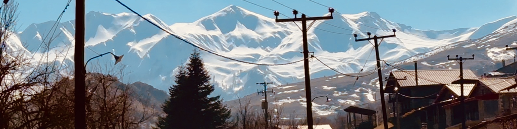

### Data Solutions Consultant & Implementation

I help businesses unlock the value of their data through thoughtful data management, custom analytics, automation, and machine learning solutions.  
Every solution is adapted to the tech stack and skills of the company so it is understandable and useful.

### Services

**Data Management**  
Collect, store, organize, and use your data securely, efficiently, and cost-effectively.

**Data Cleaning & Integration**  
Cause clean data beats any model.

**User Experience Research**  
Understand your users and design services that work.

**Data Analysis & Visualization**  
Get insights that support you in your decision making.

**Machine Learning and AI**  
Leverage your data and propel your business.

**Clinical Data Management**  
I can guide you through the Good Clinical Practice and/or ECRIN requirements for your data if you are planning a clinical trial.

### A step by step approach to set up a project

#### Step 1: Understanding the Business Problem

We begin by understanding your business goals, pain points, and key objectives. We’ll collaborate with you to clearly define what success looks like, ensuring that any solution we build addresses real business needs.

→

#### Step 2: Assessing Your Capabilities & Infrastructure

This step ensures we recommend a solution that fits your current resources and budget while also highlighting any infrastructure gaps that may need to be addressed (e.g., upgrading cloud storage, training staff, or automating workflows).

→

#### Step 3: Data Collection & Preparation

Once we understand your resources and challenges, we gather the necessary data from available sources and clean it. If there are any gaps or data silos, we address these, and ensure that the data is in a usable format.

→

#### Step 4: Exploratory Data Analysis (EDA)

We perform an initial exploration of the data to identify trends, correlations, and outliers. This helps us understand the data’s structure and nuances, allowing us to refine our approach to modeling. During this phase, we also check for data quality issues, ensuring that any patterns or insights we uncover are based on solid, clean data.

→

#### Step 5: Solution Development

After gathering insights from the data, we move forward with building the solution. Whether it’s a dashboard for visualizing key metrics or a machine learning model for predictions, we develop the solution according to your business needs and required infrastructure.

→

#### Step 6: Deployment & Continuous Improvement

We deploy the solution with existing infrastructure. For dashboards, this might involve integrating with your current BI tools. For machine learning models, it may require cloud services or deployment pipelines.

→

#### Step 7: Knowledge Transfer & Training

To ensure long-term success, we provide comprehensive training and documentation. This empowers your team to maintain the system, make data-driven decisions, and independently leverage the insights generated by the solution.

### Recent Projects

**Data management governance, processes, and infrastructure for a large academic institution**  
*Built a data management ecosystem to comply with GCP and ECRIN requirements.*

**Force prediction for anchoring of window frames**  
*Custom application and data pipeline. Training and deployment of machine learning algorithm. Currently working on MLOps to to streamline and automate the machine learning lifecycle*

*RShiny app:* [Force Prediction for Anchoring](https://varvara-mitro.shinyapps.io/Forces_RandomForest_App/)

**Expenses dashboarding and Routing Application**  
*Built a custom routing application and expense tracker for van travelers.*

*RShiny app:* [Travel dashboard](https://varvara-mitro.shinyapps.io/TEST_VanLifeDash/)

**Stack:** R, Python, RShiny, Google Cloud Platform, Automation, GitHub, Good Clinical Practice (GCP), European Clinical Research Infrastructure Network (ECRIN)

### Get in Touch

I love working with startups and small to mid-sized businesses.  
Let’s assess your needs and explore ideas together.

[LinkedIn](https://linkedin.com/in/varvara-mitropoulos) | [GitHub](https://github.com/varvi)  
✉️ Email Me

### About Me

I’m a one-person freelance data scientist based in Zürich, Switzerland.  
With a PhD in Biochemistry, ETH Zurich, a master of advanced studies in data science, ZHAW, and experience in clinical trials, project management, user experience and service design, I deliver solutions companies can actually use.

When I’m not working, you’ll find me in the mountains — I recently published a ski-touring film in Greece: [Xioni on YouTube](https://youtu.be/GAzRcDvd91g)

© Varvara Mitropoulos • Built with [Jekyll](https://jekyllrb.com)